# Border Patrol Apprehensions: 2010 vs. 2017

February 19, 2018

## Introduction

#### Since Donald Trump became President, apprehensions at the US-Mexico border have been very low compared to previous years.

- People have stopped illegally crossing the Southern border
  - due to the President's "rhetoric and aggressive push" to enforce immigration laws.
- "Would-be" immigrants may be waiting and watching instead of crossing the border.

## In this project…

- We compare the number of border patrol apprehensions in 2010 and 2017 by months and sector to see if there has been a significant decrease in apprehensions
  - Big Bend
  - Del Rio
  - El Centro
  - El Paso
  - Laredo
  - Rio Grande Valley
  - San Diego
  - Tucson
  - Yuma

## Visualization of the Data

We compare the number of apprehensions in 2010 and 2017 by months and sector in a side by side barplot. The following slides show these barplots.

## Big Bend

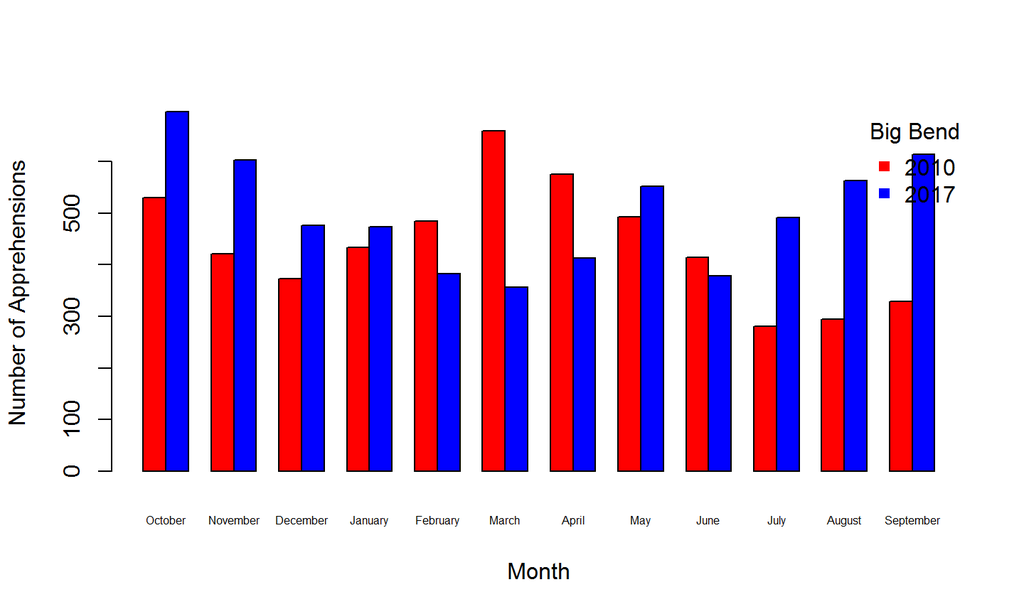

## Del Rio

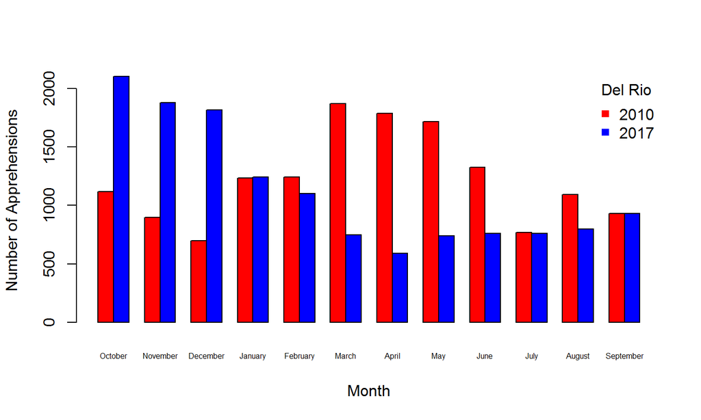

## El Centro

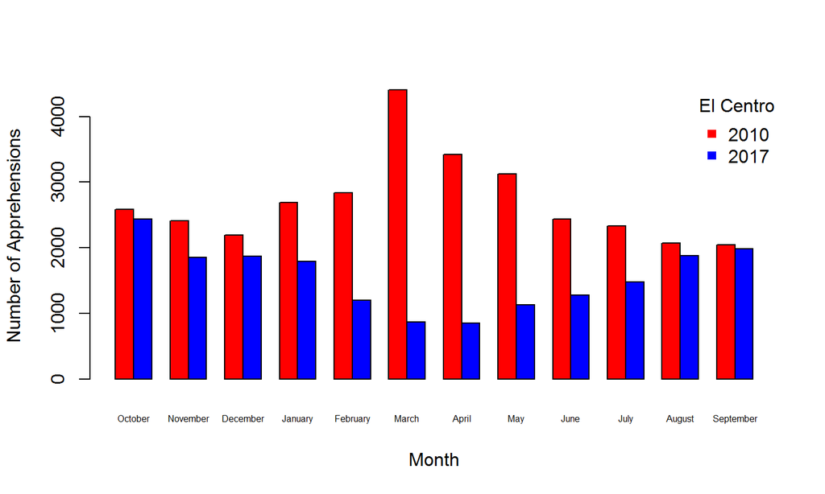

## El Paso

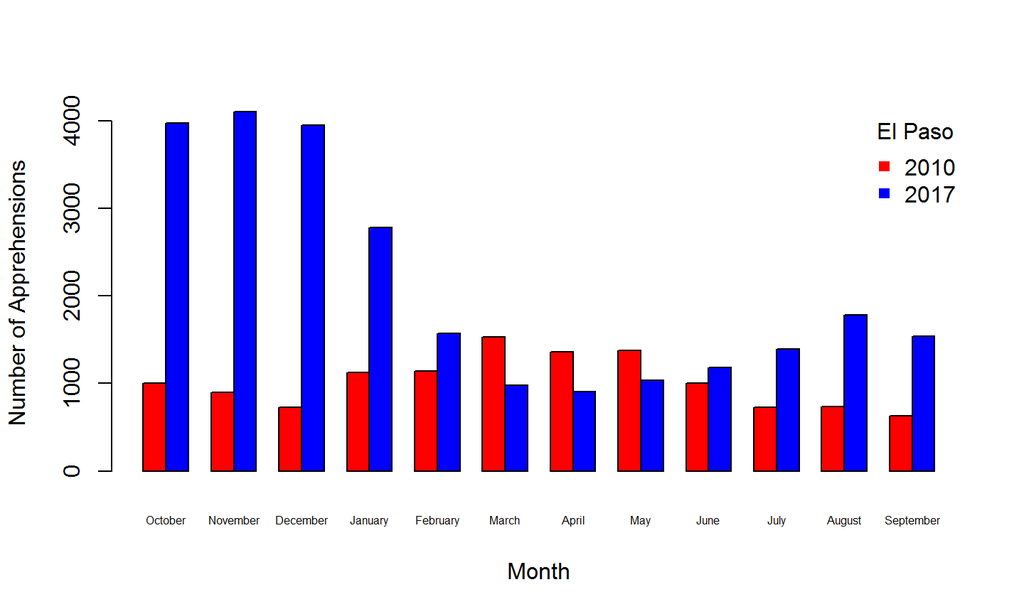

## Laredo

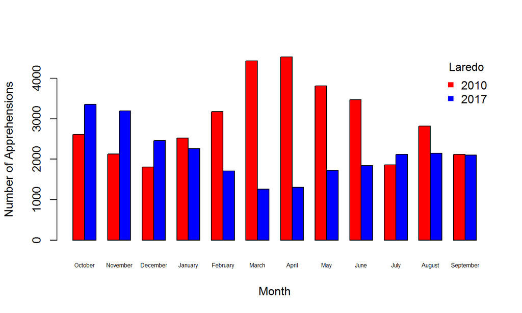

## Rio Grande Valley

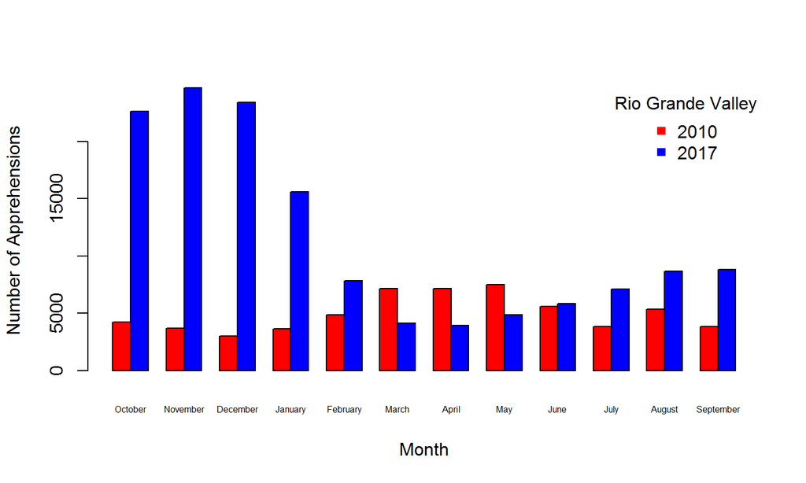

## San Diego

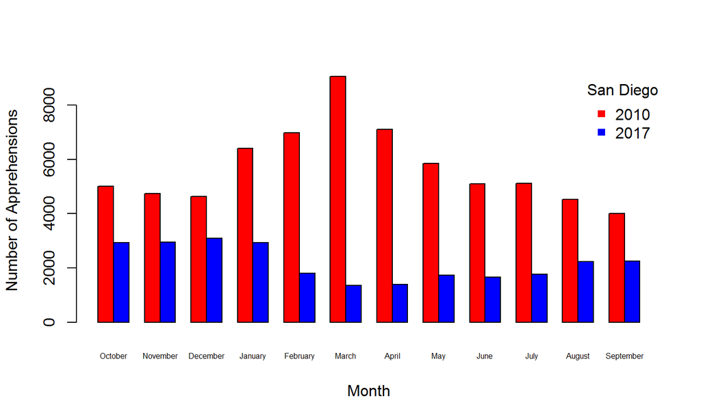

## Tucson

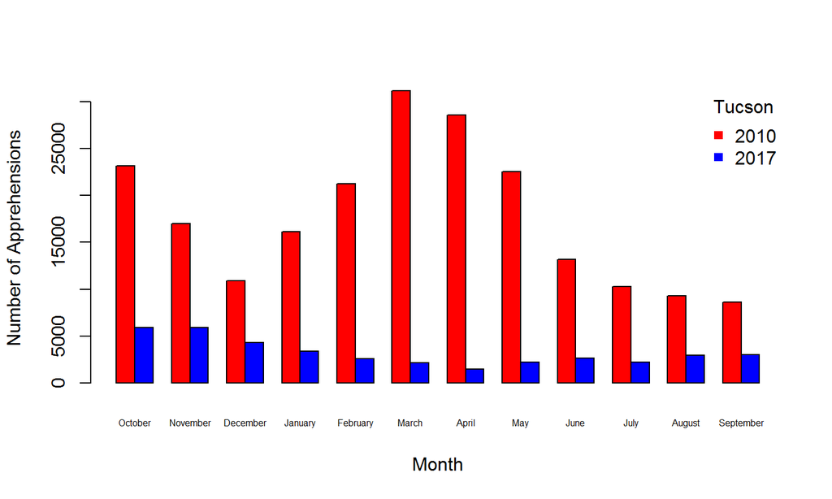

## Yuma

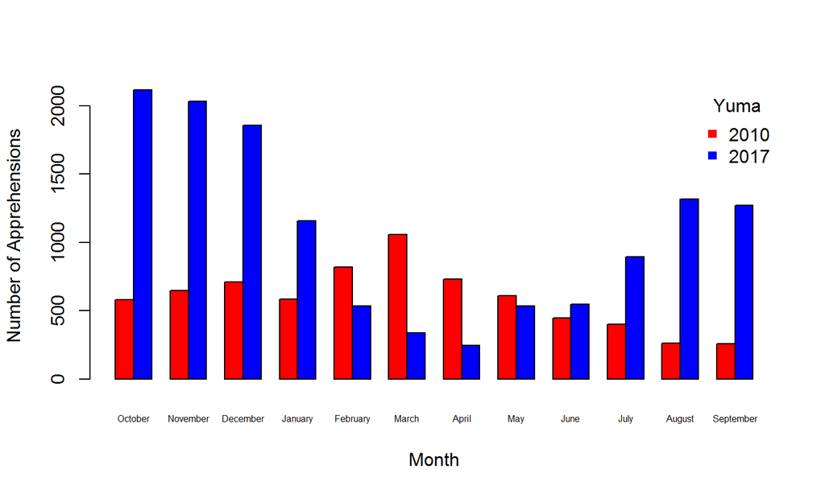

## Overview of Barplots

- Much higher number of apprehensions in 2010 between the months of February and May
- Higher number of apprehensions in 2017 between September and December
- Tucson and San Diego had the most change
- Overall large decrease in number of apprehensions from 2010 to 2017

## Statistical Testing

### Most Apprehensions by Sector

In 2010, Tucson had the most apprehensions, and in 2017, Rio Grande Valley had the most apprehensions.

```
##
##  Welch Two Sample t-test
##
## data:  earlyData[maxRowIndexOld, 1:12] and newData[maxRowIndexNew, 1:12]
## t = 1.9547, df = 21.973, p-value = 0.06346
## alternative hypothesis: true difference in means is not equal to 0
## 95 percent confidence interval:
##   -379.5935 12819.5935
## sample estimates:
## mean of x mean of y
##   17683.5   11463.5
```

- The t-test gave a t-score of 2, and a p-value of 0.06. Using an alpha of 0.05, we fail to reject the null hypothesis since the p-value is greater than alpha.
- The difference in the means of apprehensions in 2010 and 2017 are not significantly different
- The confidence interval, which is (-380, 12820), includes 0, meaning there is not a significant difference in apprehensions

### Most Apprehensions in 3 Month Period

In 2010, March, April, and May had the most apprehensions, and in 2017, October, November, and December had the most apprehensions.

```
##
##  Welch Two Sample t-test
##
## data:  c(earlyData[1:9, earlyIndex], earlyData[1:9, earlyIndex + 1],  and c(newData[1:9, newIndex], newData[1:9, newIndex + 1], newData[1:9,     earlyData[1:9, earlyIndex + 2]) and     newIndex + 2])
## t = 0.48741, df = 50.321, p-value = 0.6281
## alternative hypothesis: true difference in means is not equal to 0
## 95 percent confidence interval:
##  -3119.921  5119.699
## sample estimates:
## mean of x mean of y
##  6060.852  5060.963
```

- The t score was 0.5 and the p-value was 0.6, which is way above the alpha of 0.05. Since the p-value was above alpha, we fail to reject the null hypothesis
- The true difference in means is equal to 0, which means there is no significant difference in the means comparing most apprehensions in 3 month periods
- The confidence interval says the same since it is (-3120,5120), which includes 0, meaning the differences in means are insignificant

### Most Apprehensions Overall

Because we believed there still may be a significant difference, we took a t-test of each data as a whole in 2010 and 2017.

```
##
##  Welch Two Sample t-test
##
## data:  A2010 and A2017
## t = 0.93944, df = 226.33, p-value = 0.3485
## alternative hypothesis: true difference in means is not equal to 0
## 95 percent confidence interval:
##  -4856.601 13706.755
## sample estimates:
## mean of x mean of y
## 13776.338  9351.262
```

- Surprisingly, there was not a significant difference in the means of apprehensions
- The t test gave a t score of 0.9 and the p-value was 0.3, which is above the alpha of 0.05, meaning we fail to reject the null hypothesis, so there is no true difference between apprehensions

## Time Series

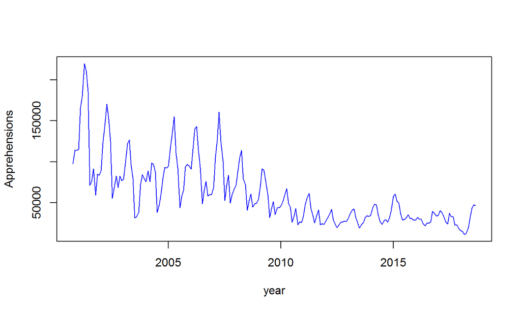

- The time series chart shows a decrease in apprehensions throughout the years from 2000 to 2017
- There seems to be a large decrease, although our statistical tests say otherwise for 2010 and 2017

## Conclusion

- There is a decrease in apprehensions throughout the years
  - because less "would-be" immigrants are crossing the border since the president has been changing immigration laws
- The t-tests don't show a significant difference between mean of apprehensions in 2010 and 2017
  - this may be because we are only comparing the maximum number of apprehensions by sectors or months in each year, disregarding what month and sector they actually are
  - if there was a comparison between each sector and each month, there may be a bigger significant difference.